# Risk Factor Analysis

## Outcome Variable

**Outcome Variable:** wast_rec90d

## Predictor Variables

**Intervention Variable:** exclfeed36

**Adjustment Set:**

- arm
- sex
- W_mage
- meducyrs
- feducyrs
- hhwealth_quart
- hfoodsec
- W_mhtcm
- vagbrth
- W_gagebrth
- W_birthwt
- W_birthlen
- W_nrooms
- W_nchldlt5
- month
- brthmon
- W_parity
- impfloor
- impsan
- safeh20
- delta_W_mage
- delta_meducyrs
- delta_feducyrs
- delta_hhwealth_quart
- delta_hfoodsec
- delta_W_mhtcm
- delta_vagbrth
- delta_W_gagebrth
- delta_W_birthwt
- delta_W_birthlen
- delta_W_nrooms
- delta_W_nchldlt5
- delta_month
- delta_brthmon
- delta_W_parity
- delta_impfloor
- delta_impsan
- delta_safeh20

## Stratifying Variables

The analysis was stratified on these variable(s):

- agecat
- studyid
- country

## Data Summary

| agecat | studyid | country | exclfeed36 | wast_rec90d | n_cell | n |
| --- | --- | --- | --- | --- | --- | --- |
| 0-24 months | ki0047075b-MAL-ED | BANGLADESH | 1 | 0 | 15 | 122 |
| 0-24 months | ki0047075b-MAL-ED | BANGLADESH | 1 | 1 | 23 | 122 |
| 0-24 months | ki0047075b-MAL-ED | BANGLADESH | 0 | 0 | 29 | 122 |
| 0-24 months | ki0047075b-MAL-ED | BANGLADESH | 0 | 1 | 55 | 122 |
| 0-24 months | ki0047075b-MAL-ED | BRAZIL | 1 | 0 | 0 | 23 |
| 0-24 months | ki0047075b-MAL-ED | BRAZIL | 1 | 1 | 0 | 23 |
| 0-24 months | ki0047075b-MAL-ED | BRAZIL | 0 | 0 | 6 | 23 |
| 0-24 months | ki0047075b-MAL-ED | BRAZIL | 0 | 1 | 17 | 23 |
| 0-24 months | ki0047075b-MAL-ED | INDIA | 1 | 0 | 0 | 177 |
| 0-24 months | ki0047075b-MAL-ED | INDIA | 1 | 1 | 3 | 177 |
| 0-24 months | ki0047075b-MAL-ED | INDIA | 0 | 0 | 70 | 177 |
| 0-24 months | ki0047075b-MAL-ED | INDIA | 0 | 1 | 104 | 177 |
| 0-24 months | ki0047075b-MAL-ED | NEPAL | 1 | 0 | 0 | 93 |
| 0-24 months | ki0047075b-MAL-ED | NEPAL | 1 | 1 | 1 | 93 |
| 0-24 months | ki0047075b-MAL-ED | NEPAL | 0 | 0 | 20 | 93 |
| 0-24 months | ki0047075b-MAL-ED | NEPAL | 0 | 1 | 72 | 93 |
| 0-24 months | ki0047075b-MAL-ED | PERU | 1 | 0 | 0 | 32 |
| 0-24 months | ki0047075b-MAL-ED | PERU | 1 | 1 | 0 | 32 |
| 0-24 months | ki0047075b-MAL-ED | PERU | 0 | 0 | 6 | 32 |
| 0-24 months | ki0047075b-MAL-ED | PERU | 0 | 1 | 26 | 32 |
| 0-24 months | ki0047075b-MAL-ED | SOUTH AFRICA | 1 | 0 | 0 | 78 |
| 0-24 months | ki0047075b-MAL-ED | SOUTH AFRICA | 1 | 1 | 0 | 78 |
| 0-24 months | ki0047075b-MAL-ED | SOUTH AFRICA | 0 | 0 | 13 | 78 |
| 0-24 months | ki0047075b-MAL-ED | SOUTH AFRICA | 0 | 1 | 65 | 78 |
| 0-24 months | ki0047075b-MAL-ED | TANZANIA, UNITED REPUBLIC OF | 1 | 0 | 0 | 45 |
| 0-24 months | ki0047075b-MAL-ED | TANZANIA, UNITED REPUBLIC OF | 1 | 1 | 0 | 45 |
| 0-24 months | ki0047075b-MAL-ED | TANZANIA, UNITED REPUBLIC OF | 0 | 0 | 8 | 45 |
| 0-24 months | ki0047075b-MAL-ED | TANZANIA, UNITED REPUBLIC OF | 0 | 1 | 37 | 45 |
| 0-24 months | ki1000108-CMC-V-BCS-2002 | INDIA | 1 | 0 | 2 | 5 |
| 0-24 months | ki1000108-CMC-V-BCS-2002 | INDIA | 1 | 1 | 3 | 5 |

[output cut: 174 more lines]

The following strata were considered:

- agecat: 0-24 months, studyid: ki0047075b-MAL-ED, country: BANGLADESH
- agecat: 0-24 months, studyid: ki0047075b-MAL-ED, country: BRAZIL
- agecat: 0-24 months, studyid: ki0047075b-MAL-ED, country: INDIA
- agecat: 0-24 months, studyid: ki0047075b-MAL-ED, country: NEPAL
- agecat: 0-24 months, studyid: ki0047075b-MAL-ED, country: PERU
- agecat: 0-24 months, studyid: ki0047075b-MAL-ED, country: SOUTH AFRICA
- agecat: 0-24 months, studyid: ki0047075b-MAL-ED, country: TANZANIA, UNITED REPUBLIC OF
- agecat: 0-24 months, studyid: ki1000108-CMC-V-BCS-2002, country: INDIA
- agecat: 0-24 months, studyid: ki1000108-IRC, country: INDIA
- agecat: 0-24 months, studyid: ki1000109-EE, country: PAKISTAN
- agecat: 0-24 months, studyid: ki1000304b-SAS-FoodSuppl, country: INDIA
- agecat: 0-24 months, studyid: ki1017093b-PROVIDE, country: BANGLADESH
- agecat: 0-24 months, studyid: ki1101329-Keneba, country: GAMBIA
- agecat: 0-24 months, studyid: ki1113344-GMS-Nepal, country: NEPAL
- agecat: 0-24 months, studyid: ki1148112-LCNI-5, country: MALAWI
- agecat: 0-24 months, studyid: kiGH5241-JiVitA-3, country: BANGLADESH
- agecat: 0-24 months, studyid: kiGH5241-JiVitA-4, country: BANGLADESH
- agecat: 0-6 months, studyid: ki0047075b-MAL-ED, country: BANGLADESH
- agecat: 0-6 months, studyid: ki0047075b-MAL-ED, country: BRAZIL
- agecat: 0-6 months, studyid: ki0047075b-MAL-ED, country: INDIA
- agecat: 0-6 months, studyid: ki0047075b-MAL-ED, country: NEPAL
- agecat: 0-6 months, studyid: ki0047075b-MAL-ED, country: PERU
- agecat: 0-6 months, studyid: ki0047075b-MAL-ED, country: SOUTH AFRICA
- agecat: 0-6 months, studyid: ki0047075b-MAL-ED, country: TANZANIA, UNITED REPUBLIC OF
- agecat: 0-6 months, studyid: ki1000108-CMC-V-BCS-2002, country: INDIA
- agecat: 0-6 months, studyid: ki1000108-IRC, country: INDIA
- agecat: 0-6 months, studyid: ki1000109-EE, country: PAKISTAN
- agecat: 0-6 months, studyid: ki1000304b-SAS-FoodSuppl, country: INDIA
- agecat: 0-6 months, studyid: ki1017093b-PROVIDE, country: BANGLADESH
- agecat: 0-6 months, studyid: ki1101329-Keneba, country: GAMBIA
- agecat: 0-6 months, studyid: ki1113344-GMS-Nepal, country: NEPAL
- agecat: 0-6 months, studyid: ki1148112-LCNI-5, country: MALAWI
- agecat: 0-6 months, studyid: kiGH5241-JiVitA-3, country: BANGLADESH
- agecat: 0-6 months, studyid: kiGH5241-JiVitA-4, country: BANGLADESH
- agecat: 6-24 months, studyid: ki0047075b-MAL-ED, country: BANGLADESH
- agecat: 6-24 months, studyid: ki0047075b-MAL-ED, country: BRAZIL
- agecat: 6-24 months, studyid: ki0047075b-MAL-ED, country: INDIA
- agecat: 6-24 months, studyid: ki0047075b-MAL-ED, country: NEPAL
- agecat: 6-24 months, studyid: ki0047075b-MAL-ED, country: PERU
- agecat: 6-24 months, studyid: ki0047075b-MAL-ED, country: SOUTH AFRICA
- agecat: 6-24 months, studyid: ki0047075b-MAL-ED, country: TANZANIA, UNITED REPUBLIC OF
- agecat: 6-24 months, studyid: ki1000108-CMC-V-BCS-2002, country: INDIA
- agecat: 6-24 months, studyid: ki1000108-IRC, country: INDIA
- agecat: 6-24 months, studyid: ki1000109-EE, country: PAKISTAN
- agecat: 6-24 months, studyid: ki1000304b-SAS-FoodSuppl, country: INDIA
- agecat: 6-24 months, studyid: ki1017093b-PROVIDE, country: BANGLADESH
- agecat: 6-24 months, studyid: ki1101329-Keneba, country: GAMBIA
- agecat: 6-24 months, studyid: ki1113344-GMS-Nepal, country: NEPAL
- agecat: 6-24 months, studyid: ki1148112-LCNI-5, country: MALAWI
- agecat: 6-24 months, studyid: kiGH5241-JiVitA-3, country: BANGLADESH
- agecat: 6-24 months, studyid: kiGH5241-JiVitA-4, country: BANGLADESH

### Dropped Strata

Some strata were dropped due to rare outcomes:

- agecat: 0-24 months, studyid: ki0047075b-MAL-ED, country: BRAZIL
- agecat: 0-24 months, studyid: ki0047075b-MAL-ED, country: INDIA
- agecat: 0-24 months, studyid: ki0047075b-MAL-ED, country: NEPAL
- agecat: 0-24 months, studyid: ki0047075b-MAL-ED, country: PERU
- agecat: 0-24 months, studyid: ki0047075b-MAL-ED, country: SOUTH AFRICA
- agecat: 0-24 months, studyid: ki0047075b-MAL-ED, country: TANZANIA, UNITED REPUBLIC OF
- agecat: 0-24 months, studyid: ki1000108-CMC-V-BCS-2002, country: INDIA
- agecat: 0-24 months, studyid: ki1000108-IRC, country: INDIA
- agecat: 0-24 months, studyid: ki1000304b-SAS-FoodSuppl, country: INDIA
- agecat: 0-24 months, studyid: ki1148112-LCNI-5, country: MALAWI
- agecat: 0-6 months, studyid: ki0047075b-MAL-ED, country: BANGLADESH
- agecat: 0-6 months, studyid: ki0047075b-MAL-ED, country: BRAZIL
- agecat: 0-6 months, studyid: ki0047075b-MAL-ED, country: INDIA
- agecat: 0-6 months, studyid: ki0047075b-MAL-ED, country: NEPAL
- agecat: 0-6 months, studyid: ki0047075b-MAL-ED, country: PERU
- agecat: 0-6 months, studyid: ki0047075b-MAL-ED, country: SOUTH AFRICA
- agecat: 0-6 months, studyid: ki0047075b-MAL-ED, country: TANZANIA, UNITED REPUBLIC OF
- agecat: 0-6 months, studyid: ki1000108-CMC-V-BCS-2002, country: INDIA
- agecat: 0-6 months, studyid: ki1000108-IRC, country: INDIA
- agecat: 0-6 months, studyid: ki1000304b-SAS-FoodSuppl, country: INDIA
- agecat: 0-6 months, studyid: ki1017093b-PROVIDE, country: BANGLADESH
- agecat: 0-6 months, studyid: ki1148112-LCNI-5, country: MALAWI
- agecat: 6-24 months, studyid: ki0047075b-MAL-ED, country: BRAZIL
- agecat: 6-24 months, studyid: ki0047075b-MAL-ED, country: INDIA
- agecat: 6-24 months, studyid: ki0047075b-MAL-ED, country: NEPAL
- agecat: 6-24 months, studyid: ki0047075b-MAL-ED, country: PERU
- agecat: 6-24 months, studyid: ki0047075b-MAL-ED, country: SOUTH AFRICA
- agecat: 6-24 months, studyid: ki0047075b-MAL-ED, country: TANZANIA, UNITED REPUBLIC OF
- agecat: 6-24 months, studyid: ki1000108-CMC-V-BCS-2002, country: INDIA
- agecat: 6-24 months, studyid: ki1000108-IRC, country: INDIA
- agecat: 6-24 months, studyid: ki1000304b-SAS-FoodSuppl, country: INDIA
- agecat: 6-24 months, studyid: ki1148112-LCNI-5, country: MALAWI
- agecat: 6-24 months, studyid: kiGH5241-JiVitA-3, country: BANGLADESH

## Methods Detail

We’re interested in the causal parameters $E[Y_a]$ for all values of $a \in \mathcal{A}$. These parameters represent the mean outcome if, possibly contrary to fact, we intervened to set all units to have $A=a$. Under the randomization and positivity assumptions, these are identified by the statistical parameters $\psi_a=E_W[E_{Y|A,W}(Y|A=a,W)]$. In addition, we’re interested in the mean of $Y$, $E[Y]$ under no intervention (the observed mean). We will estimate these parameters by using SuperLearner to fit the relevant likelihood factors – $E_{Y|A,W}(Y|A=a,W)$ and $p(A=a|W)$, and then updating our likelihood fit using a joint TMLE.

For unadjusted analyses ($W=\{\}$), initial likelihoods were estimated using Lrnr_glm to estimate the simple $E(Y|A)$ and Lrnr_mean to estimate $p(A)$. For adjusted analyses, a small library containing Lrnr_glmnet, Lrnr_xgboost, and Lrnr_mean was used.

Having estimated these parameters, we will then use the delta method to estimate relative risks and attributable risks relative to a prespecified baseline level of $A$.

# Results Detail

## Results Plots

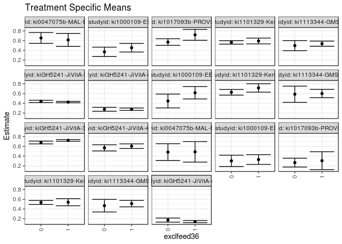

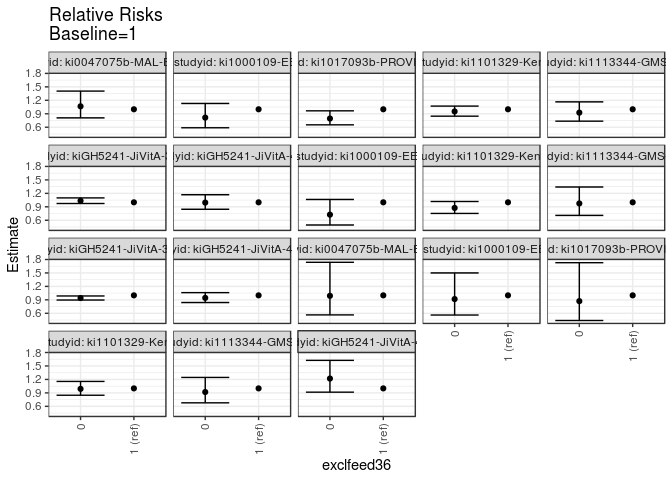

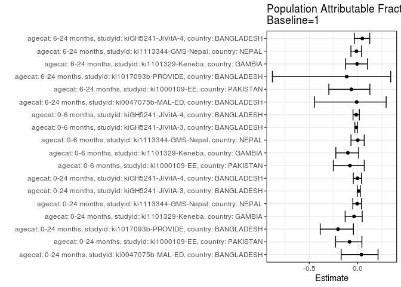

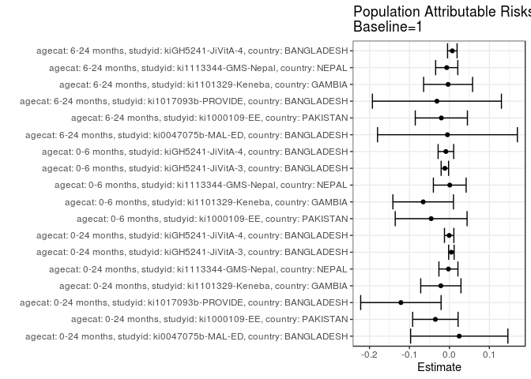

## Results Table

### Parameter: TSM

| agecat | studyid | country | intervention_level | baseline_level | estimate | ci_lower | ci_upper |
| --- | --- | --- | --- | --- | --- | --- | --- |
| 0-24 months | ki0047075b-MAL-ED | BANGLADESH | 1 | NA | 0.6147375 | 0.4813483 | 0.7481266 |
| 0-24 months | ki0047075b-MAL-ED | BANGLADESH | 0 | NA | 0.6552255 | 0.5438985 | 0.7665524 |
| 0-24 months | ki1000109-EE | PAKISTAN | 1 | NA | 0.4547944 | 0.3662560 | 0.5433328 |
| 0-24 months | ki1000109-EE | PAKISTAN | 0 | NA | 0.3705230 | 0.2737131 | 0.4673328 |
| 0-24 months | ki1017093b-PROVIDE | BANGLADESH | 1 | NA | 0.7194383 | 0.6071942 | 0.8316824 |
| 0-24 months | ki1017093b-PROVIDE | BANGLADESH | 0 | NA | 0.5711118 | 0.5040465 | 0.6381771 |
| 0-24 months | ki1101329-Keneba | GAMBIA | 1 | NA | 0.5928708 | 0.5331605 | 0.6525811 |
| 0-24 months | ki1101329-Keneba | GAMBIA | 0 | NA | 0.5643856 | 0.5293667 | 0.5994044 |
| 0-24 months | ki1113344-GMS-Nepal | NEPAL | 1 | NA | 0.5380378 | 0.4848809 | 0.5911946 |
| 0-24 months | ki1113344-GMS-Nepal | NEPAL | 0 | NA | 0.4979425 | 0.3944367 | 0.6014482 |
| 0-24 months | kiGH5241-JiVitA-3 | BANGLADESH | 1 | NA | 0.4242905 | 0.4097748 | 0.4388063 |
| 0-24 months | kiGH5241-JiVitA-3 | BANGLADESH | 0 | NA | 0.4387682 | 0.4154446 | 0.4620917 |
| 0-24 months | kiGH5241-JiVitA-4 | BANGLADESH | 1 | NA | 0.2787901 | 0.2541556 | 0.3034246 |
| 0-24 months | kiGH5241-JiVitA-4 | BANGLADESH | 0 | NA | 0.2771023 | 0.2373368 | 0.3168678 |
| 0-6 months | ki1000109-EE | PAKISTAN | 1 | NA | 0.6157830 | 0.4892552 | 0.7423108 |
| 0-6 months | ki1000109-EE | PAKISTAN | 0 | NA | 0.4464985 | 0.3045484 | 0.5884486 |
| 0-6 months | ki1101329-Keneba | GAMBIA | 1 | NA | 0.7144930 | 0.6278864 | 0.8010996 |
| 0-6 months | ki1101329-Keneba | GAMBIA | 0 | NA | 0.6250847 | 0.5672441 | 0.6829252 |
| 0-6 months | ki1113344-GMS-Nepal | NEPAL | 1 | NA | 0.6003479 | 0.5148132 | 0.6858827 |
| 0-6 months | ki1113344-GMS-Nepal | NEPAL | 0 | NA | 0.5852101 | 0.4189963 | 0.7514239 |
| 0-6 months | kiGH5241-JiVitA-3 | BANGLADESH | 1 | NA | 0.7236329 | 0.7062326 | 0.7410333 |
| 0-6 months | kiGH5241-JiVitA-3 | BANGLADESH | 0 | NA | 0.6804540 | 0.6512422 | 0.7096658 |
| 0-6 months | kiGH5241-JiVitA-4 | BANGLADESH | 1 | NA | 0.6045089 | 0.5569466 | 0.6520711 |
| 0-6 months | kiGH5241-JiVitA-4 | BANGLADESH | 0 | NA | 0.5706222 | 0.5072397 | 0.6340048 |
| 6-24 months | ki0047075b-MAL-ED | BANGLADESH | 1 | NA | 0.4887682 | 0.2783250 | 0.6992114 |
| 6-24 months | ki0047075b-MAL-ED | BANGLADESH | 0 | NA | 0.4838105 | 0.3120773 | 0.6555437 |
| 6-24 months | ki1000109-EE | PAKISTAN | 1 | NA | 0.3310198 | 0.2313425 | 0.4306971 |
| 6-24 months | ki1000109-EE | PAKISTAN | 0 | NA | 0.3036353 | 0.1871830 | 0.4200875 |
| 6-24 months | ki1017093b-PROVIDE | BANGLADESH | 1 | NA | 0.3076923 | 0.1243207 | 0.4910639 |
| 6-24 months | ki1017093b-PROVIDE | BANGLADESH | 0 | NA | 0.2680412 | 0.1773699 | 0.3587126 |
| 6-24 months | ki1101329-Keneba | GAMBIA | 1 | NA | 0.5402899 | 0.4669179 | 0.6136620 |
| 6-24 months | ki1101329-Keneba | GAMBIA | 0 | NA | 0.5345437 | 0.4933167 | 0.5757707 |
| 6-24 months | ki1113344-GMS-Nepal | NEPAL | 1 | NA | 0.5111238 | 0.4454518 | 0.5767958 |
| 6-24 months | ki1113344-GMS-Nepal | NEPAL | 0 | NA | 0.4696554 | 0.3408420 | 0.5984688 |
| 6-24 months | kiGH5241-JiVitA-4 | BANGLADESH | 1 | NA | 0.1429882 | 0.1209195 | 0.1650569 |
| 6-24 months | kiGH5241-JiVitA-4 | BANGLADESH | 0 | NA | 0.1743936 | 0.1322790 | 0.2165082 |

### Parameter: E(Y)

| agecat | studyid | country | intervention_level | baseline_level | estimate | ci_lower | ci_upper |
| --- | --- | --- | --- | --- | --- | --- | --- |
| 0-24 months | ki0047075b-MAL-ED | BANGLADESH | NA | NA | 0.6393443 | 0.5530901 | 0.7255985 |
| 0-24 months | ki1000109-EE | PAKISTAN | NA | NA | 0.4196078 | 0.3541827 | 0.4850330 |
| 0-24 months | ki1017093b-PROVIDE | BANGLADESH | NA | NA | 0.5979381 | 0.5402414 | 0.6556349 |
| 0-24 months | ki1101329-Keneba | GAMBIA | NA | NA | 0.5714286 | 0.5409902 | 0.6018670 |
| 0-24 months | ki1113344-GMS-Nepal | NEPAL | NA | NA | 0.5355731 | 0.4882587 | 0.5828875 |
| 0-24 months | kiGH5241-JiVitA-3 | BANGLADESH | NA | NA | 0.4292213 | 0.4164001 | 0.4420426 |
| 0-24 months | kiGH5241-JiVitA-4 | BANGLADESH | NA | NA | 0.2781828 | 0.2567503 | 0.2996153 |
| 0-6 months | ki1000109-EE | PAKISTAN | NA | NA | 0.5700935 | 0.4742263 | 0.6659606 |
| 0-6 months | ki1101329-Keneba | GAMBIA | NA | NA | 0.6487936 | 0.6002638 | 0.6973233 |
| 0-6 months | ki1113344-GMS-Nepal | NEPAL | NA | NA | 0.6012270 | 0.5255442 | 0.6769098 |
| 0-6 months | kiGH5241-JiVitA-3 | BANGLADESH | NA | NA | 0.7122532 | 0.6971343 | 0.7273720 |
| 0-6 months | kiGH5241-JiVitA-4 | BANGLADESH | NA | NA | 0.5957031 | 0.5531528 | 0.6382534 |
| 6-24 months | ki0047075b-MAL-ED | BANGLADESH | NA | NA | 0.4838710 | 0.3544124 | 0.6133295 |
| 6-24 months | ki1000109-EE | PAKISTAN | NA | NA | 0.3108108 | 0.2352987 | 0.3863229 |
| 6-24 months | ki1017093b-PROVIDE | BANGLADESH | NA | NA | 0.2764228 | 0.1950773 | 0.3577682 |
| 6-24 months | ki1101329-Keneba | GAMBIA | NA | NA | 0.5369928 | 0.5007974 | 0.5731883 |
| 6-24 months | ki1113344-GMS-Nepal | NEPAL | NA | NA | 0.5043732 | 0.4466684 | 0.5620780 |
| 6-24 months | kiGH5241-JiVitA-4 | BANGLADESH | NA | NA | 0.1502754 | 0.1309788 | 0.1695719 |

### Parameter: RR

| agecat | studyid | country | intervention_level | baseline_level | estimate | ci_lower | ci_upper |
| --- | --- | --- | --- | --- | --- | --- | --- |
| 0-24 months | ki0047075b-MAL-ED | BANGLADESH | 1 | 1 | 1.0000000 | 1.0000000 | 1.0000000 |
| 0-24 months | ki0047075b-MAL-ED | BANGLADESH | 0 | 1 | 1.0658622 | 0.8084355 | 1.4052602 |
| 0-24 months | ki1000109-EE | PAKISTAN | 1 | 1 | 1.0000000 | 1.0000000 | 1.0000000 |
| 0-24 months | ki1000109-EE | PAKISTAN | 0 | 1 | 0.8147044 | 0.5874474 | 1.1298768 |
| 0-24 months | ki1017093b-PROVIDE | BANGLADESH | 1 | 1 | 1.0000000 | 1.0000000 | 1.0000000 |
| 0-24 months | ki1017093b-PROVIDE | BANGLADESH | 0 | 1 | 0.7938301 | 0.6526894 | 0.9654919 |
| 0-24 months | ki1101329-Keneba | GAMBIA | 1 | 1 | 1.0000000 | 1.0000000 | 1.0000000 |
| 0-24 months | ki1101329-Keneba | GAMBIA | 0 | 1 | 0.9519538 | 0.8464556 | 1.0706008 |
| 0-24 months | ki1113344-GMS-Nepal | NEPAL | 1 | 1 | 1.0000000 | 1.0000000 | 1.0000000 |
| 0-24 months | ki1113344-GMS-Nepal | NEPAL | 0 | 1 | 0.9254787 | 0.7349481 | 1.1654030 |
| 0-24 months | kiGH5241-JiVitA-3 | BANGLADESH | 1 | 1 | 1.0000000 | 1.0000000 | 1.0000000 |
| 0-24 months | kiGH5241-JiVitA-3 | BANGLADESH | 0 | 1 | 1.0341220 | 0.9736947 | 1.0982995 |
| 0-24 months | kiGH5241-JiVitA-4 | BANGLADESH | 1 | 1 | 1.0000000 | 1.0000000 | 1.0000000 |
| 0-24 months | kiGH5241-JiVitA-4 | BANGLADESH | 0 | 1 | 0.9939459 | 0.8449999 | 1.1691463 |
| 0-6 months | ki1000109-EE | PAKISTAN | 1 | 1 | 1.0000000 | 1.0000000 | 1.0000000 |
| 0-6 months | ki1000109-EE | PAKISTAN | 0 | 1 | 0.7250906 | 0.4942332 | 1.0637819 |
| 0-6 months | ki1101329-Keneba | GAMBIA | 1 | 1 | 1.0000000 | 1.0000000 | 1.0000000 |
| 0-6 months | ki1101329-Keneba | GAMBIA | 0 | 1 | 0.8748647 | 0.7517941 | 1.0180823 |
| 0-6 months | ki1113344-GMS-Nepal | NEPAL | 1 | 1 | 1.0000000 | 1.0000000 | 1.0000000 |
| 0-6 months | ki1113344-GMS-Nepal | NEPAL | 0 | 1 | 0.9747849 | 0.7081509 | 1.3418123 |
| 0-6 months | kiGH5241-JiVitA-3 | BANGLADESH | 1 | 1 | 1.0000000 | 1.0000000 | 1.0000000 |
| 0-6 months | kiGH5241-JiVitA-3 | BANGLADESH | 0 | 1 | 0.9403304 | 0.8959306 | 0.9869305 |
| 0-6 months | kiGH5241-JiVitA-4 | BANGLADESH | 1 | 1 | 1.0000000 | 1.0000000 | 1.0000000 |
| 0-6 months | kiGH5241-JiVitA-4 | BANGLADESH | 0 | 1 | 0.9439435 | 0.8401354 | 1.0605782 |
| 6-24 months | ki0047075b-MAL-ED | BANGLADESH | 1 | 1 | 1.0000000 | 1.0000000 | 1.0000000 |
| 6-24 months | ki0047075b-MAL-ED | BANGLADESH | 0 | 1 | 0.9898568 | 0.5639979 | 1.7372697 |
| 6-24 months | ki1000109-EE | PAKISTAN | 1 | 1 | 1.0000000 | 1.0000000 | 1.0000000 |
| 6-24 months | ki1000109-EE | PAKISTAN | 0 | 1 | 0.9172722 | 0.5609653 | 1.4998935 |
| 6-24 months | ki1017093b-PROVIDE | BANGLADESH | 1 | 1 | 1.0000000 | 1.0000000 | 1.0000000 |
| 6-24 months | ki1017093b-PROVIDE | BANGLADESH | 0 | 1 | 0.8711340 | 0.4389733 | 1.7287486 |
| 6-24 months | ki1101329-Keneba | GAMBIA | 1 | 1 | 1.0000000 | 1.0000000 | 1.0000000 |
| 6-24 months | ki1101329-Keneba | GAMBIA | 0 | 1 | 0.9893645 | 0.8475106 | 1.1549616 |
| 6-24 months | ki1113344-GMS-Nepal | NEPAL | 1 | 1 | 1.0000000 | 1.0000000 | 1.0000000 |
| 6-24 months | ki1113344-GMS-Nepal | NEPAL | 0 | 1 | 0.9188682 | 0.6782753 | 1.2448024 |
| 6-24 months | kiGH5241-JiVitA-4 | BANGLADESH | 1 | 1 | 1.0000000 | 1.0000000 | 1.0000000 |
| 6-24 months | kiGH5241-JiVitA-4 | BANGLADESH | 0 | 1 | 1.2196361 | 0.9155097 | 1.6247915 |

### Parameter: PAR

| agecat | studyid | country | intervention_level | baseline_level | estimate | ci_lower | ci_upper |
| --- | --- | --- | --- | --- | --- | --- | --- |
| 0-24 months | ki0047075b-MAL-ED | BANGLADESH | 1 | NA | 0.0246068 | -0.0971617 | 0.1463752 |
| 0-24 months | ki1000109-EE | PAKISTAN | 1 | NA | -0.0351865 | -0.0920809 | 0.0217078 |
| 0-24 months | ki1017093b-PROVIDE | BANGLADESH | 1 | NA | -0.1215002 | -0.2221922 | -0.0208082 |
| 0-24 months | ki1101329-Keneba | GAMBIA | 1 | NA | -0.0214422 | -0.0718323 | 0.0289479 |
| 0-24 months | ki1113344-GMS-Nepal | NEPAL | 1 | NA | -0.0024646 | -0.0262511 | 0.0213218 |
| 0-24 months | kiGH5241-JiVitA-3 | BANGLADESH | 1 | NA | 0.0049308 | -0.0019676 | 0.0118292 |
| 0-24 months | kiGH5241-JiVitA-4 | BANGLADESH | 1 | NA | -0.0006073 | -0.0123535 | 0.0111390 |
| 0-6 months | ki1000109-EE | PAKISTAN | 1 | NA | -0.0456896 | -0.1356500 | 0.0442709 |
| 0-6 months | ki1101329-Keneba | GAMBIA | 1 | NA | -0.0656994 | -0.1415340 | 0.0101352 |
| 0-6 months | ki1113344-GMS-Nepal | NEPAL | 1 | NA | 0.0008791 | -0.0401613 | 0.0419194 |
| 0-6 months | kiGH5241-JiVitA-3 | BANGLADESH | 1 | NA | -0.0113797 | -0.0206664 | -0.0020931 |
| 0-6 months | kiGH5241-JiVitA-4 | BANGLADESH | 1 | NA | -0.0088058 | -0.0283049 | 0.0106934 |
| 6-24 months | ki0047075b-MAL-ED | BANGLADESH | 1 | NA | -0.0048972 | -0.1800152 | 0.1702207 |
| 6-24 months | ki1000109-EE | PAKISTAN | 1 | NA | -0.0202090 | -0.0854837 | 0.0450656 |
| 6-24 months | ki1017093b-PROVIDE | BANGLADESH | 1 | NA | -0.0312695 | -0.1927776 | 0.1302386 |
| 6-24 months | ki1101329-Keneba | GAMBIA | 1 | NA | -0.0032971 | -0.0645890 | 0.0579948 |
| 6-24 months | ki1113344-GMS-Nepal | NEPAL | 1 | NA | -0.0067506 | -0.0344848 | 0.0209835 |
| 6-24 months | kiGH5241-JiVitA-4 | BANGLADESH | 1 | NA | 0.0072872 | -0.0046578 | 0.0192321 |

### Parameter: PAF

| agecat | studyid | country | intervention_level | baseline_level | estimate | ci_lower | ci_upper |
| --- | --- | --- | --- | --- | --- | --- | --- |
| 0-24 months | ki0047075b-MAL-ED | BANGLADESH | 1 | NA | 0.0384875 | -0.1708788 | 0.2104168 |
| 0-24 months | ki1000109-EE | PAKISTAN | 1 | NA | -0.0838557 | -0.2283654 | 0.0436532 |
| 0-24 months | ki1017093b-PROVIDE | BANGLADESH | 1 | NA | -0.2031986 | -0.3869314 | -0.0438056 |
| 0-24 months | ki1101329-Keneba | GAMBIA | 1 | NA | -0.0375239 | -0.1295164 | 0.0469764 |
| 0-24 months | ki1113344-GMS-Nepal | NEPAL | 1 | NA | -0.0046019 | -0.0500092 | 0.0388418 |
| 0-24 months | kiGH5241-JiVitA-3 | BANGLADESH | 1 | NA | 0.0114878 | -0.0047167 | 0.0274310 |
| 0-24 months | kiGH5241-JiVitA-4 | BANGLADESH | 1 | NA | -0.0021830 | -0.0453071 | 0.0391620 |
| 0-6 months | ki1000109-EE | PAKISTAN | 1 | NA | -0.0801440 | -0.2518630 | 0.0680201 |
| 0-6 months | ki1101329-Keneba | GAMBIA | 1 | NA | -0.1012640 | -0.2255404 | 0.0104101 |
| 0-6 months | ki1113344-GMS-Nepal | NEPAL | 1 | NA | 0.0014621 | -0.0691833 | 0.0674397 |
| 0-6 months | kiGH5241-JiVitA-3 | BANGLADESH | 1 | NA | -0.0159771 | -0.0291187 | -0.0030033 |
| 0-6 months | kiGH5241-JiVitA-4 | BANGLADESH | 1 | NA | -0.0147821 | -0.0480194 | 0.0174010 |
| 6-24 months | ki0047075b-MAL-ED | BANGLADESH | 1 | NA | -0.0101209 | -0.4456368 | 0.2941905 |
| 6-24 months | ki1000109-EE | PAKISTAN | 1 | NA | -0.0650203 | -0.2979478 | 0.1261064 |
| 6-24 months | ki1017093b-PROVIDE | BANGLADESH | 1 | NA | -0.1131222 | -0.8811275 | 0.3413307 |
| 6-24 months | ki1101329-Keneba | GAMBIA | 1 | NA | -0.0061399 | -0.1269729 | 0.1017374 |
| 6-24 months | ki1113344-GMS-Nepal | NEPAL | 1 | NA | -0.0133842 | -0.0698052 | 0.0400613 |
| 6-24 months | kiGH5241-JiVitA-4 | BANGLADESH | 1 | NA | 0.0484921 | -0.0342632 | 0.1246259 |